# IE360 - Homework 2

Emre Karadas - 2018402255

13/05/2022

## Required Packages

```r
library(zoo)
library(corrplot)
library(dplyr)
library(readxl)
library(lubridate)
library(ggplot2)
library(dplyr)
require(urca)
require(GGally)
require(forecast)
require(data.table)
```

## 1. Introduction

At the bottom, reading of the data is done. Also, the first and the last year data are shown:

```r
data_path <- "IE360_Spring22_HW2_data.csv"
data <- read.csv(data_path)

data$Unleaded.Gasoline.Sale..UGS. = gsub(" ", "", data$Unleaded.Gasoline.Sale..UGS.)
data$Unleaded.Gasoline.Sale..UGS. = as.numeric(data$Unleaded.Gasoline.Sale..UGS.)

data$X..LPG.Vehicles..NLPG. = gsub(" ", "", data$X..LPG.Vehicles..NLPG.)
data$X..LPG.Vehicles..NLPG. = as.numeric(data$X..LPG.Vehicles..NLPG)

data$X..Unleaded.Gasoline.Vehicles..NUGV. = gsub(" ", "", data$X..Unleaded.Gasoline.Vehicles..NUGV.)
data$X..Unleaded.Gasoline.Vehicles..NUGV. = as.numeric(data$X..Unleaded.Gasoline.Vehicles..NUGV.)

data$GNP.Agriculture = gsub(" ", "", data$GNP.Agriculture)
data$GNP.Agriculture = as.numeric(data$GNP.Agriculture)

data$GNP.Commerce = gsub(" ", "", data$GNP.Commerce)
data$GNP.Commerce = as.numeric(data$GNP.Commerce)

data$GNP.Total = gsub(" ", "", data$GNP.Total)
data$GNP.Total = as.numeric(data$GNP.Total)

data$Quarter = as.character(data$Quarter)
data = data.table(data)
```

First Year:

```r
head(data,4)
```

```
##    Quarter Unleaded.Gasoline.Sale..UGS.   RNUV X..LPG.Vehicles..NLPG.
## 1: 2000_Q1                      1128971 0.0146                 940000
## 2: 2000_Q2                      1199569 0.0205                 941000
## 3: 2000_Q3                      1370167 0.0207                 943500
## 4: 2000_Q4                      1127548 0.0163                 948000
##    Price.of.Unleaded.Gasoline..PU. Price.of.Diesel.Gasoline..PG.
## 1:                          469.03                        355.69
## 2:                          459.42                        344.58
## 3:                          439.98                        327.21
## 4:                          402.08                        300.67
##    X..Unleaded.Gasoline.Vehicles..NUGV.
## 1:                              4647500
## 2:                              4742876
## 3:                              4840931
## 4:                              4919685
##    X..of.Diesel.Gasoline.Vehicles..NDGV. GNP.Agriculture GNP.Commerce
## 1:                              281.9853         1040173      3483132
## 2:                              284.0813         1760460      4525451
## 3:                              286.7169         6974808      5915204
## 4:                              288.3137         3267125      4929778
##    GNP.Total
## 1:  18022686
## 2:  21797130
## 3:  30050207
## 4:  24480153
```

Last Year:

```r
tail(data,4)
```

```
##    Quarter Unleaded.Gasoline.Sale..UGS.   RNUV X..LPG.Vehicles..NLPG.
## 1: 2007_Q1                           NA 0.0074                1715000
## 2: 2007_Q2                           NA 0.0106                1725300
## 3: 2007_Q3                           NA 0.0101                1751050
## 4: 2007_Q4                           NA 0.0124                1797400
##    Price.of.Unleaded.Gasoline..PU. Price.of.Diesel.Gasoline..PG.
## 1:                          565.19                        449.19
## 2:                          565.19                        449.19
## 3:                          565.19                        449.19
## 4:                          565.19                        449.19
##    X..Unleaded.Gasoline.Vehicles..NUGV.
## 1:                              5869018
## 2:                              5931348
## 3:                              5991280
## 4:                              6065597
##    X..of.Diesel.Gasoline.Vehicles..NDGV. GNP.Agriculture GNP.Commerce
## 1:                              342.1729         1132973      4857305
## 2:                              346.9407         1570703      5852404
## 3:                              351.4449         7140722      7480414
## 4:                              357.2902         2418541      6397745
##    GNP.Total
## 1:  24413807
## 2:  27597857
## 3:  36741745
## 4:  31361112
```

## 2. Plotted Data

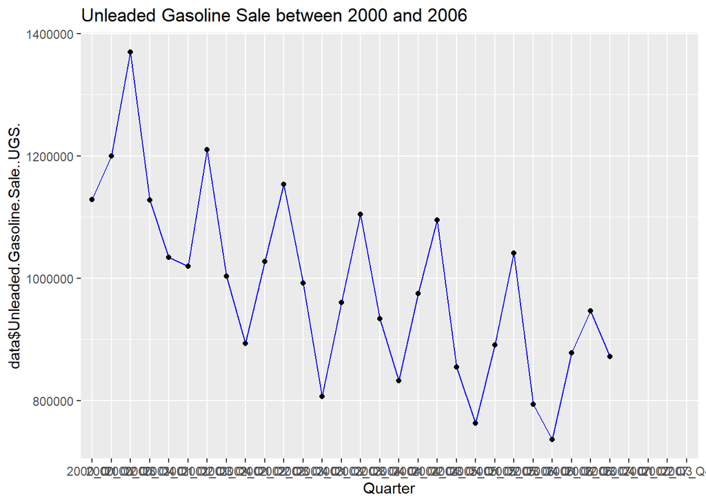

```r
data$UGS = ts(data$Unleaded.Gasoline.Sale..UGS., start = 2000, deltat= 1/4)
ggplot(data, aes(Quarter,data$Unleaded.Gasoline.Sale..UGS. , group=1)) + geom_line(color="blue") +geom_point()+ ggtitle("Unleaded Gasoline Sale between 2000 and 2006")
```

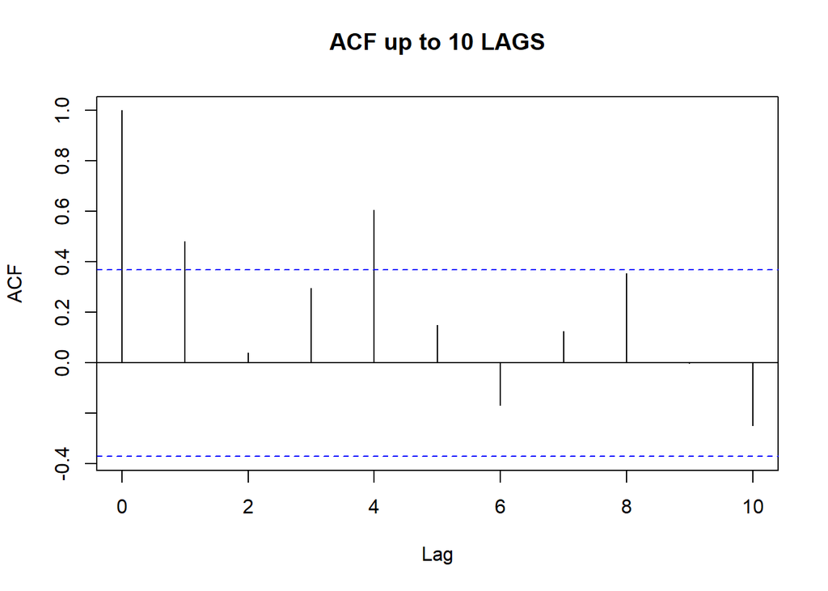

```r
acf(data$Unleaded.Gasoline.Sale..UGS.[0:28], 10, main="ACF up to 10 LAGS")
```

The time series is significantly autocorrelated on lag 1 and 4.

```r
data[ , trend := 1 :.N]
```

Trend is added to the data.

```r
seasonality_period <- 4
data[ , seasonality := (1:.N) %% seasonality_period]
```

Seasonality is added to the data.

```r
data[seasonality == 0, seasonality := 4]
```

Arranging numbers to see the seasonality.

```r
data$seasonality = as.factor(data$seasonality)
summary(data)
```

```
##    Quarter          Unleaded.Gasoline.Sale..UGS.      RNUV
##  Length:32          Min.   : 736580              Min.   :0.001200
##  Class :character   1st Qu.: 876211              1st Qu.:0.004100
##  Mode  :character   Median : 983573              Median :0.007250
##                     Mean   : 987212              Mean   :0.008906
##                     3rd Qu.:1097324              3rd Qu.:0.013150
##                     Max.   :1370167              Max.   :0.020700
##                     NA's   :4
##  X..LPG.Vehicles..NLPG. Price.of.Unleaded.Gasoline..PU.
##  Min.   : 940000        Min.   :402.1
##  1st Qu.: 997500        1st Qu.:479.2
##  Median :1352000        Median :526.7
##  Mean   :1299922        Mean   :519.2
##  3rd Qu.:1602000        3rd Qu.:565.2
##  Max.   :1797400        Max.   :609.0
##
##  Price.of.Diesel.Gasoline..PG. X..Unleaded.Gasoline.Vehicles..NUGV.
##  Min.   :300.7                 Min.   :4647500
##  1st Qu.:366.9                 1st Qu.:5029281
##  Median :401.6                 Median :5186068
##  Mean   :400.4                 Mean   :5296758
##  3rd Qu.:449.2                 3rd Qu.:5604709
##  Max.   :471.9                 Max.   :6065597
##
##  X..of.Diesel.Gasoline.Vehicles..NDGV. GNP.Agriculture    GNP.Commerce
##  Min.   :282.0                         Min.   : 832953   Min.   :3374849
##  1st Qu.:286.6                         1st Qu.:1348066   1st Qu.:4403081
##  Median :291.9                         Median :1850657   Median :5124300
##  Mean   :304.9                         Mean   :2895561   Mean   :5246534
##  3rd Qu.:322.9                         3rd Qu.:3922950   3rd Qu.:5967433
##  Max.   :357.3                         Max.   :7140722   Max.   :7480414
##
##    GNP.Total             UGS              trend       seasonality
##  Min.   :15832648   Min.   : 736580   Min.   : 1.00   1:8
##  1st Qu.:21790148   1st Qu.: 876211   1st Qu.: 8.75   2:8
##  Median :25229712   Median : 983573   Median :16.50   3:8
##  Mean   :25745763   Mean   : 987212   Mean   :16.50   4:8
##  3rd Qu.:29843404   3rd Qu.:1097324   3rd Qu.:24.25
##  Max.   :36741745   Max.   :1370167   Max.   :32.00
##                     NA's   :4
```

## 3. Alternative Regression Models

Model will be improved by using different variables to decide the best model.

Model 1: Initial Model.

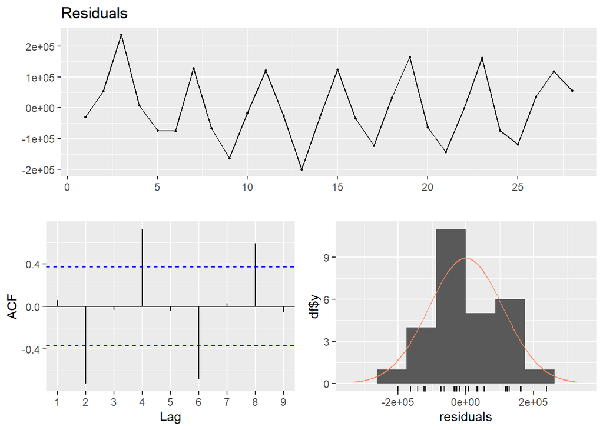

```r
Model_1 = lm(Unleaded.Gasoline.Sale..UGS.~trend ,data)
checkresiduals(Model_1$residuals)
```

```r
summary(Model_1)
```

```
##
## Call:
## lm(formula = Unleaded.Gasoline.Sale..UGS. ~ trend, data = data)
##
## Residuals:
##     Min      1Q  Median      3Q     Max
## -199945  -73550  -21904   71224  237369
##
## Coefficients:
##             Estimate Std. Error t value Pr(>|t|)
## (Intercept)  1170777      43293  27.043  < 2e-16 ***
## trend         -12660       2608  -4.854 4.95e-05 ***
## ---
## Signif. codes:  0 '***' 0.001 '**' 0.01 '*' 0.05 '.' 0.1 ' ' 1
##
## Residual standard error: 111500 on 26 degrees of freedom
##   (4 observations deleted due to missingness)
## Multiple R-squared:  0.4754, Adjusted R-squared:  0.4552
## F-statistic: 23.56 on 1 and 26 DF,  p-value: 4.945e-05
```

Model 2: In this model, seasonality will be added to the model.

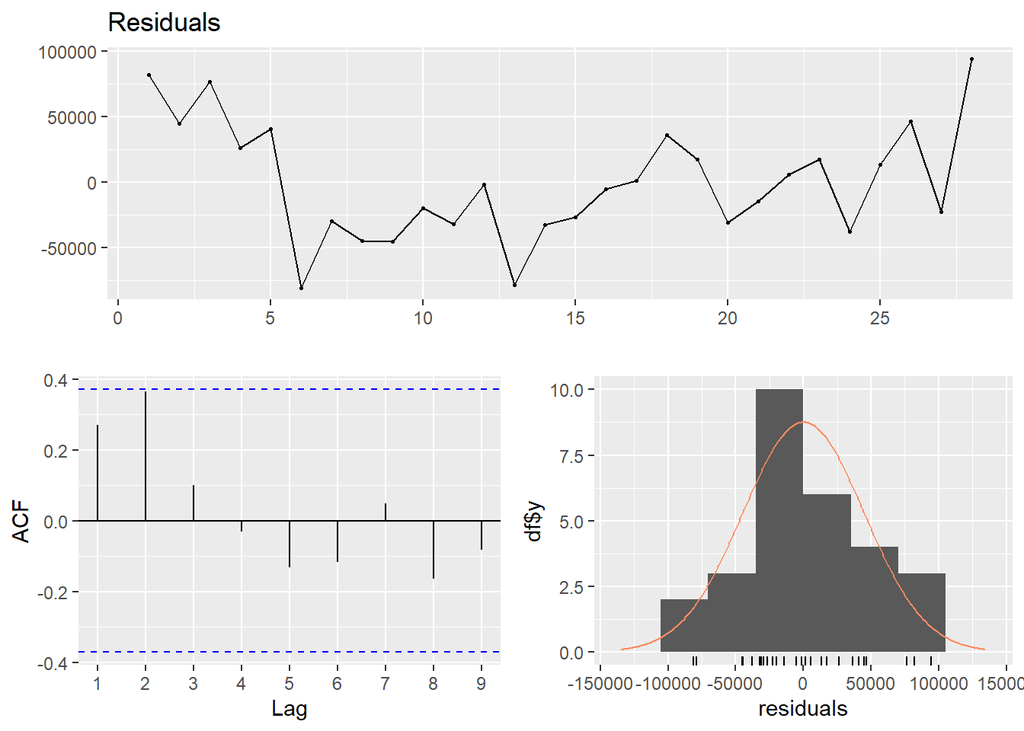

```r
Model_2 = lm(Unleaded.Gasoline.Sale..UGS.~trend + seasonality ,data)
checkresiduals(Model_2$residuals)
```

```r
summary(Model_2)
```

```
##
## Call:
## lm(formula = Unleaded.Gasoline.Sale..UGS. ~ trend + seasonality,
##     data = data)
##
## Residuals:
##    Min     1Q Median     3Q    Max
## -81167 -31283  -3458  28640  94502
##
## Coefficients:
##              Estimate Std. Error t value Pr(>|t|)
## (Intercept)   1060372      23653  44.830  < 2e-16 ***
## trend          -13497       1147 -11.764 3.28e-11 ***
## seasonality2   121532      25987   4.677 0.000104 ***
## seasonality3   273619      26063  10.498 3.03e-10 ***
## seasonality4    95049      26189   3.629 0.001405 **
## ---
## Signif. codes:  0 '***' 0.001 '**' 0.01 '*' 0.05 '.' 0.1 ' ' 1
##
## Residual standard error: 48570 on 23 degrees of freedom
##   (4 observations deleted due to missingness)
## Multiple R-squared:  0.9119, Adjusted R-squared:  0.8966
## F-statistic: 59.53 on 4 and 23 DF,  p-value: 8.446e-12
```

Model_2’s Autocorrelation seems better than the Model_1.

Model 3: In this model, Adjusted R square will be developed by adding different indepent variables.

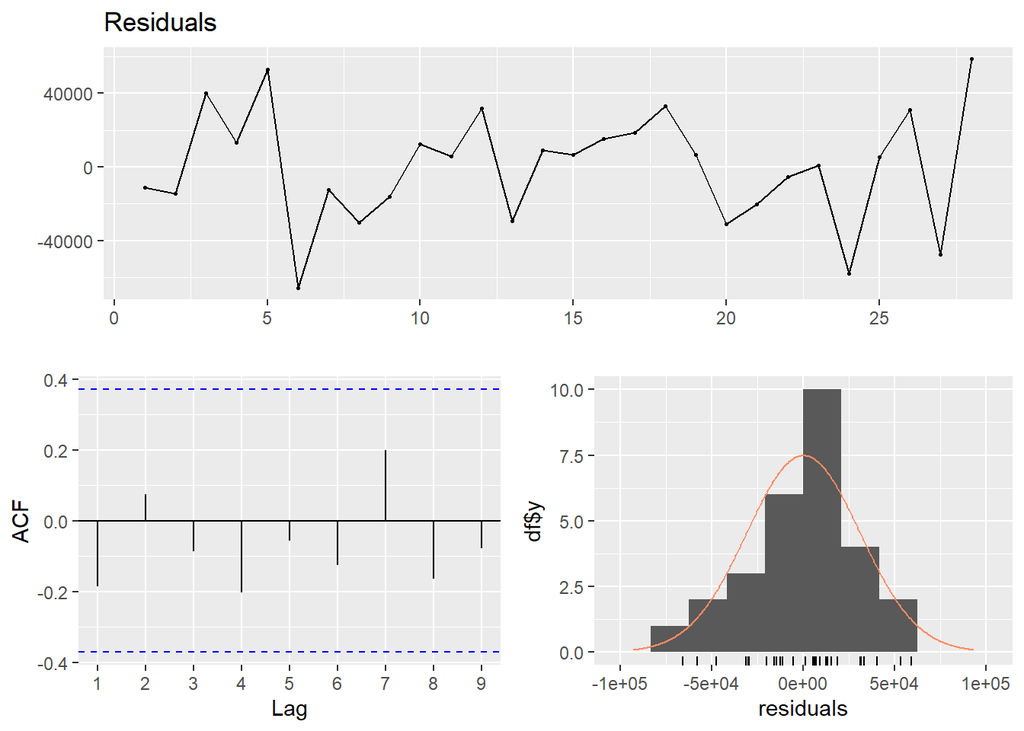

```r
Model_3 = lm(Unleaded.Gasoline.Sale..UGS.~trend +
            seasonality +
            X..of.Diesel.Gasoline.Vehicles..NDGV. +
            GNP.Commerce +
            X..Unleaded.Gasoline.Vehicles..NUGV.,
data)
checkresiduals(Model_3$residuals)
```

```r
summary(Model_3)
```

```
##
## Call:
## lm(formula = Unleaded.Gasoline.Sale..UGS. ~ trend + seasonality +
##     X..of.Diesel.Gasoline.Vehicles..NDGV. + GNP.Commerce + X..Unleaded.Gasoline.Vehicles..NUGV.,
##     data = data)
##
## Residuals:
##    Min     1Q Median     3Q    Max
## -65995 -17029   5510  16120  58902
##
## Coefficients:
##                                         Estimate Std. Error t value
## (Intercept)                            1.955e+06  6.415e+05   3.048
## trend                                 -4.234e+03  6.481e+03  -0.653
## seasonality2                           1.451e+05  4.915e+04   2.952
## seasonality3                           3.380e+05  1.276e+05   2.649
## seasonality4                           1.389e+05  7.181e+04   1.935
## X..of.Diesel.Gasoline.Vehicles..NDGV.  7.387e+03  2.205e+03   3.350
## GNP.Commerce                          -2.377e-02  5.147e-02  -0.462
## X..Unleaded.Gasoline.Vehicles..NUGV.  -6.048e-01  2.206e-01  -2.741
##                                       Pr(>|t|)
## (Intercept)                            0.00635 **
## trend                                  0.52098
## seasonality2                           0.00789 **
## seasonality3                           0.01539 *
## seasonality4                           0.06729 .
## X..of.Diesel.Gasoline.Vehicles..NDGV.  0.00319 **
## GNP.Commerce                           0.64919
## X..Unleaded.Gasoline.Vehicles..NUGV.   0.01259 *
## ---
## Signif. codes:  0 '***' 0.001 '**' 0.01 '*' 0.05 '.' 0.1 ' ' 1
##
## Residual standard error: 36100 on 20 degrees of freedom
##   (4 observations deleted due to missingness)
## Multiple R-squared:  0.9577, Adjusted R-squared:  0.9429
## F-statistic: 64.65 on 7 and 20 DF,  p-value: 2.372e-12
```

## 4. Conclusion

I visualized the statistics to get a sense of the big picture. I noticed that the data has a declining trend and seasonality. As a result of the stationary definition, I have concluded that this data is not stationary. Then, the approaches described in the “Alternative Regression Models” section, I developed a regression model to forecast data for the coming year. Unfortunately, I am unable to make forecasts for 2007.